# Airport Stock Prediction by Latency

Yoni Getahon

2026-05-19

# Setup and Data Loading

I use [Alphavantage](https://www.alphavantage.co/documentation/) site for stock monthly information API query: and the [Bureau of Transportation Statistics (BTS)](https://www.transtats.bts.gov/OT_Delay/OT_DelayCause1.asp) for of all carriers’ monthly delay data.

The fuel data is from [Fred](https://fred.stlouisfed.org/series/WJFUELUSGULF#)

## Import Data

```r
delay_data<- read_csv(here("data", "delay_data.csv"))

DAL<- read_csv(here("data","DAL_month.csv")) %>%
  mutate(Carrier= "DAL")
UAL<- read_csv(here("data","UAL_month.csv")) %>%
  mutate(Carrier= "UAL")
JBLU<- read_csv(here("data","JBLU_month.csv")) %>%
  mutate(Carrier= "JBLU")
AAL<- read_csv(here("data","AAL_month.csv")) %>%
  mutate(Carrier= "AAL")
ALK<- read_csv(here("data","ALK_month.csv")) %>%
  mutate(Carrier= "ALK")
HA<- read_csv(here("data","HA_month.csv")) %>%
  mutate(Carrier= "HA")
ULCC<- read_csv(here("data","ULCC_month.csv")) %>%
  mutate(Carrier= "ULCC")
LUV<- read_csv(here("data","LUV_month.csv")) %>%
  mutate(Carrier= "LUV")

carrier_names<-  read_csv(here("data","Airline_Delay_Cause_26.csv")) %>%
  dplyr::select(carrier,carrier_name) %>%
  distinct(carrier, .keep_all = TRUE) %>%
  arrange(carrier)
```

# Data Handling

## Data Cleaning

```r
all_stock<- bind_rows(DAL,UAL,JBLU,AAL,ALK, HA, ULCC,LUV) %>%
  rename(S_Date= timestamp) %>%
  mutate(month= month(S_Date),
         M_day= day(S_Date),
         year= year(S_Date))

rm(DAL,UAL,JBLU,AAL,ALK, HA, ULCC,LUV)
```

### Combine all Data

The dependent variable “grow_log” captures intra-month price movement, rather than a traditional month-over-month return. This reduces noise from carry-over effects between months, at the cost of not capturing the full calendar-month return investors experience.

I use $\frac{close}{open}$, which will later be used in log model, due to the advantages of a logarithmic model in predicting percentage change.

### Data dates panel:

```
## # A tibble: 8 × 4
##   carrier Start      End        Observations
##   <chr>   <date>     <date>            <int>
## 1 AAL     2005-10-31 2025-10-22          241
## 2 ALK     2003-06-30 2025-10-22          269
## 3 DAL     2007-06-29 2025-10-22          221
## 4 HA      2003-11-28 2024-09-18          250
## 5 JBLU    2003-06-30 2025-10-22          269
## 6 LUV     2003-06-30 2025-10-22          269
## 7 UAL     2006-03-31 2025-10-22          236
## 8 ULCC    2021-05-28 2025-10-22           54
```

# Exploratory Data Analysis (EDA)

### preview

Here is a preview of the structure of each of the variables in the data

```r
modelsummary::datasummary_skim(av_delay_df)
```

Unique

Missing Pct.

Mean

SD

Min

Median

Max

Histogram

year

23

0

2014.9

6.2

2003.0

2015.0

2025.0

[figure not shown]

month

12

0

6.5

3.4

1.0

7.0

12.0

[figure not shown]

arr_delay

1804

0

485850.9

448607.9

1003.0

381936.0

3181457.0

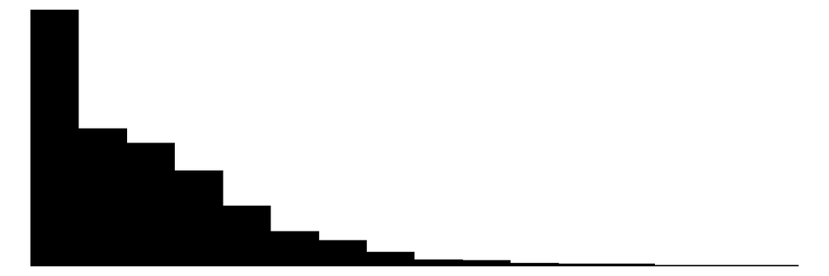

arr_flights

1783

0

42928.2

33710.9

1283.0

35230.0

128588.0

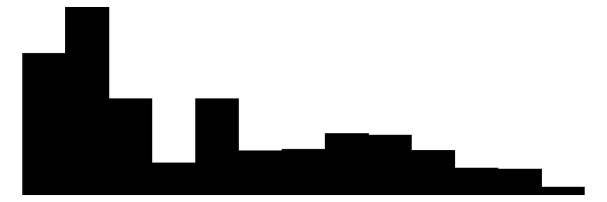

av_delay

1809

0

10.8

6.2

0.5

9.7

46.7

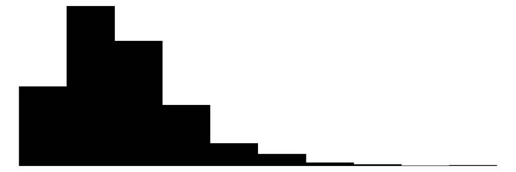

open

1520

0

29.0

21.2

1.4

23.3

103.0

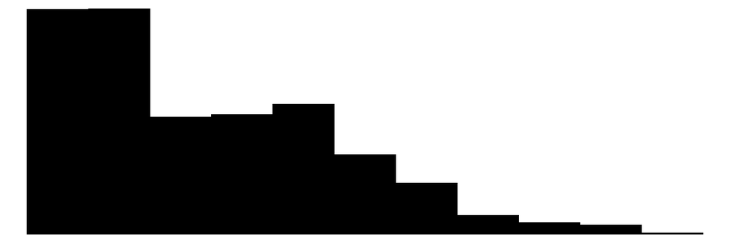

high

1586

0

31.6

22.7

2.8

25.6

116.0

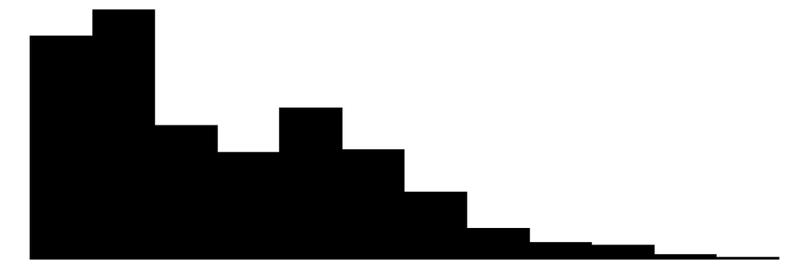

low

1548

0

26.4

19.8

1.3

20.5

94.8

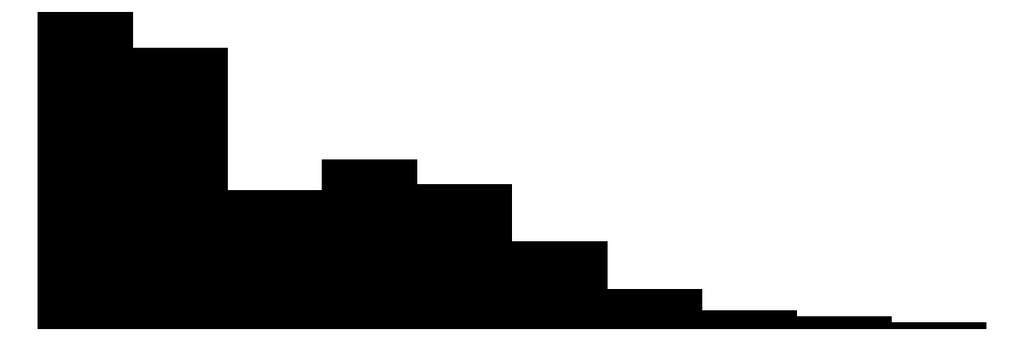

close

1559

0

29.0

21.3

2.4

23.2

105.8

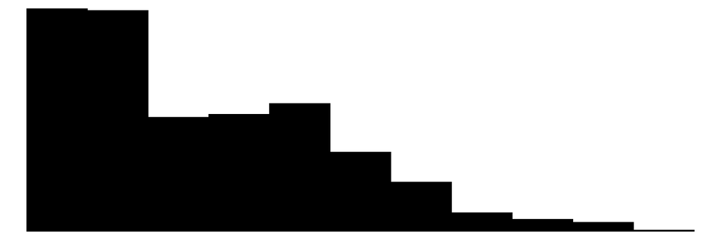

volume

1809

0

167962562.7

227013039.8

526500.0

115170576.0

3103907239.0

[figure not shown]

M_day

8

0

29.9

1.2

18.0

30.0

31.0

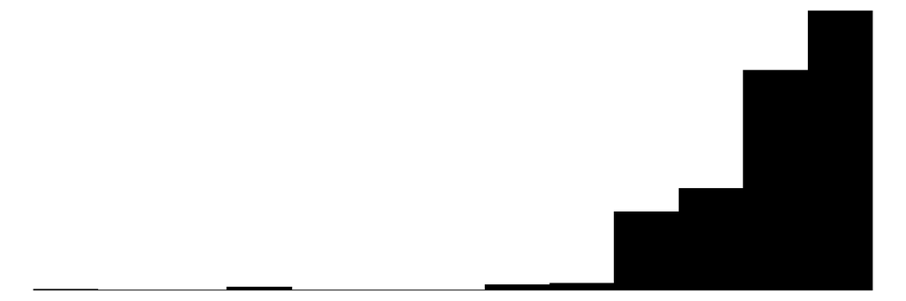

grow

1804

0

0.0

0.2

-0.5

0.0

2.2

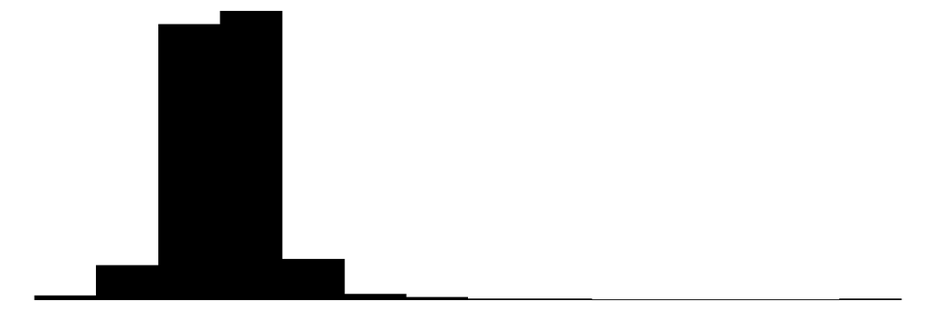

grow_log

1798

0

1.0

0.2

0.5

1.0

3.2

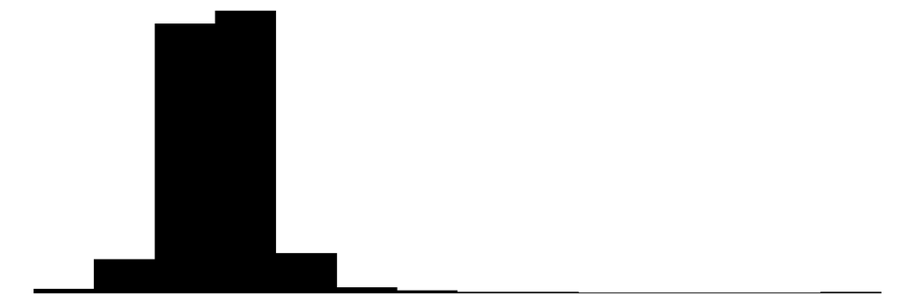

Fuel_price

256

0

2.2

0.7

0.7

2.1

4.1

[figure not shown]

fuel_del

269

0

0.0

0.1

-0.4

0.0

0.5

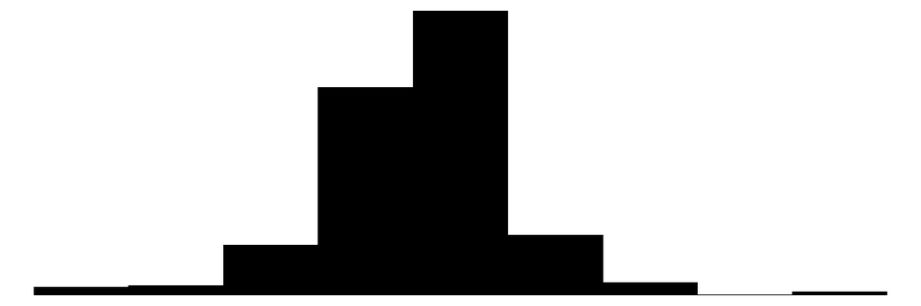

N

%

carrier

AAL

241

13.3

ALK

269

14.9

DAL

221

12.2

HA

250

13.8

JBLU

269

14.9

LUV

269

14.9

UAL

236

13.0

ULCC

54

3.0

post_corona

FALSE

1292

71.4

TRUE

517

28.6

decade

0

439

24.3

1

839

46.4

2

531

29.4

### Correlation Graphs

here is a correlation table of the main numeric variables. some have obvious correlation like the open and close of the same date and firm.

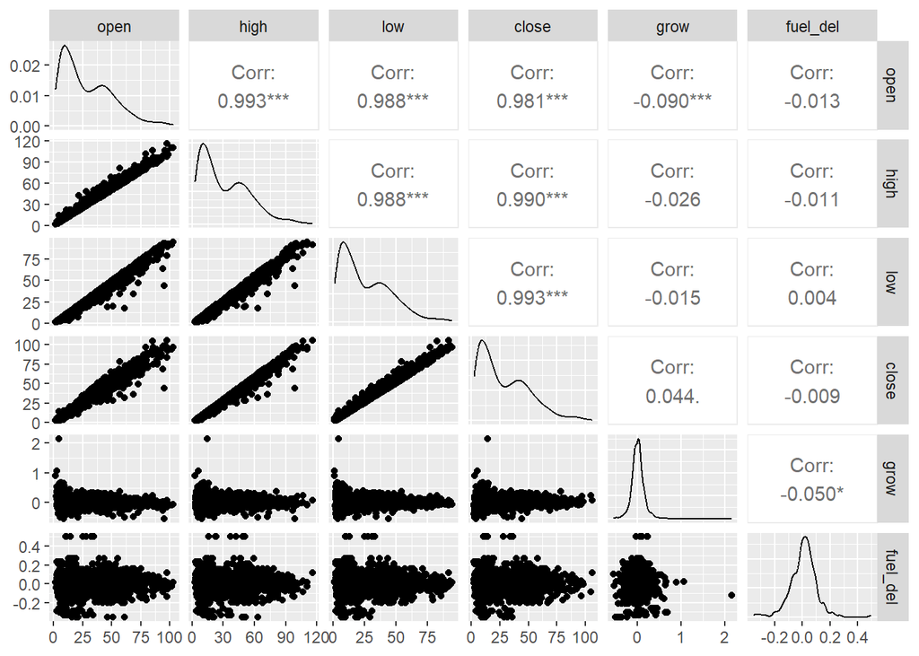

```r
av_delay_df %>%
  mutate(month= as.factor(month)) %>%
  select(8:11,14,19) %>%
GGally::ggpairs()
```

### Growth Correlation

```
##        AAL   ALK   DAL    HA  JBLU   LUV   UAL  ULCC
## AAL  1.000 0.575 0.774 0.376 0.636 0.532 0.791 0.696
## ALK  0.575 1.000 0.645 0.333 0.589 0.477 0.575 0.781
## DAL  0.774 0.645 1.000 0.420 0.649 0.611 0.797 0.716
## HA   0.376 0.333 0.420 1.000 0.371 0.379 0.316 0.472
## JBLU 0.636 0.589 0.649 0.371 1.000 0.539 0.597 0.734
## LUV  0.532 0.477 0.611 0.379 0.539 1.000 0.526 0.553
## UAL  0.791 0.575 0.797 0.316 0.597 0.526 1.000 0.661
## ULCC 0.696 0.781 0.716 0.472 0.734 0.553 0.661 1.000
```

### Data Density

Stock value at close over time and the effect of COVID-19

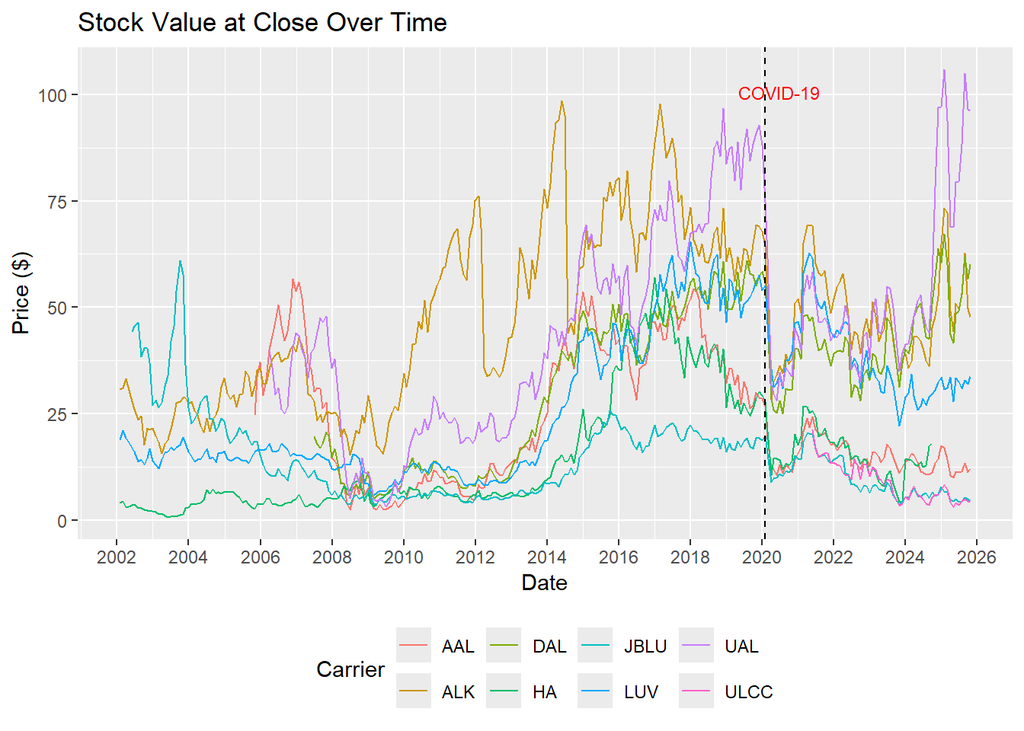

### Predicting grow by year with month and carrier effect

```r
feols(
  grow ~ year | Carrier + factor(month),
  data = (all_stock %>%
            mutate(grow= close/open)),
  cluster = ~ Carrier)
```

```
## OLS estimation, Dep. Var.: grow
## Observations: 1,954
## Fixed-effects: Carrier: 8,  factor(month): 12
## Standard-errors: Clustered (Carrier)
##      Estimate Std. Error   t value Pr(>|t|)
## year -1.5e-05   0.000221 -0.068495  0.94731
## ---
## Signif. codes:  0 '***' 0.001 '**' 0.01 '*' 0.05 '.' 0.1 ' ' 1
## RMSE: 0.15097     Adj. R2: 0.019468
##                 Within R2: 4.376e-7
```

### Month effect

```r
delay_data %>%
select(airport,carrier,year, month, arr_delay, arr_flights) %>%
  group_by(month) %>%
  summarise(
    arr_delay = sum(arr_delay, na.rm = TRUE),
    arr_flights = sum(arr_flights, na.rm = TRUE),
    .groups = "drop"
  ) %>%
  mutate(av_delay= arr_delay/arr_flights) %>%
  select(-arr_delay,-arr_flights)
```

```
## # A tibble: 12 × 2
##    month av_delay
##    <dbl>    <dbl>
##  1     1    10.8
##  2     2    10.4
##  3     3    10.6
##  4     4    10.6
##  5     5    11.7
##  6     6    15.0
##  7     7    15.5
##  8     8    12.8
##  9     9     8.34
## 10    10     8.50
## 11    11     8.37
## 12    12    12.5
```

### stock growth by month

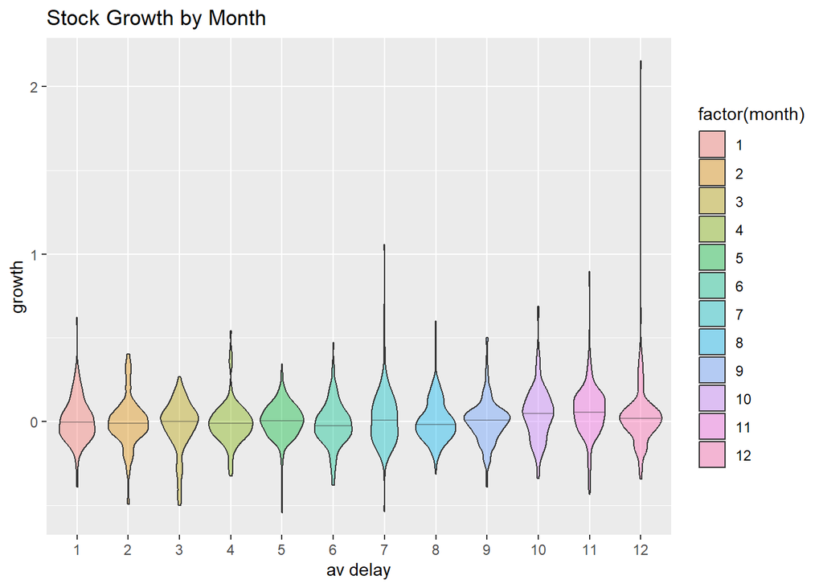

### Average stock grow by month and year as pixel graph

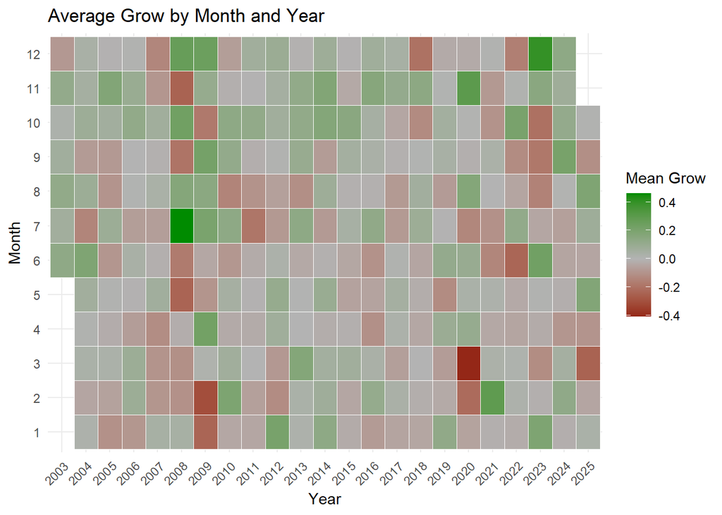

### Average delay over time and the COVID-19 effect

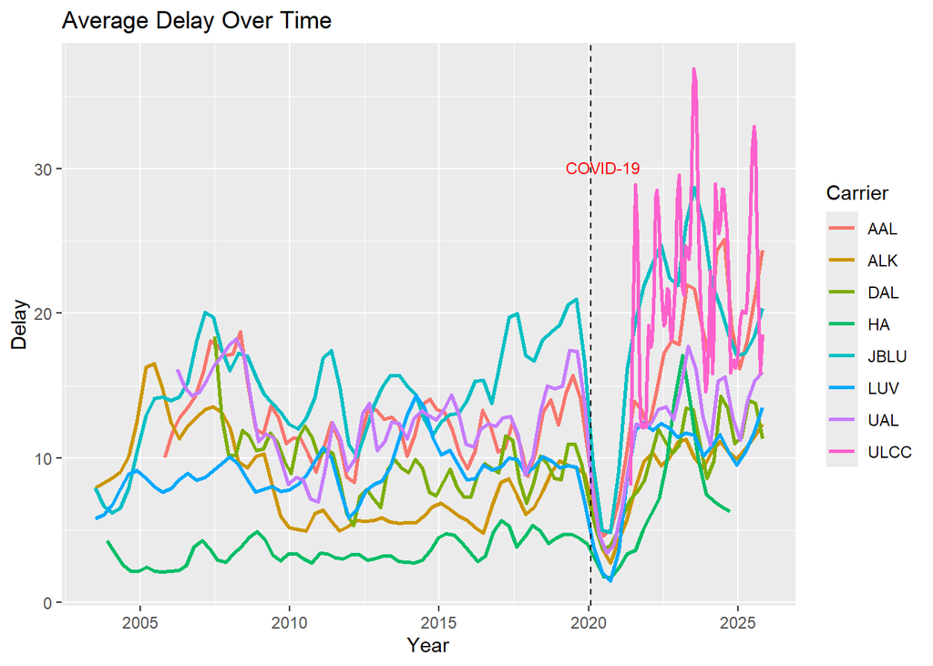

We can see that the 2020 change not only the delays, but also the variance of the delays.

### Average fuel price as a predictor of the stock growth

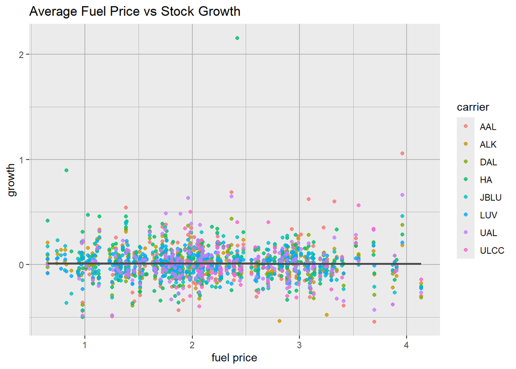

It seems like there is no clear correlation, at least not without variables handling

### LM by carrier

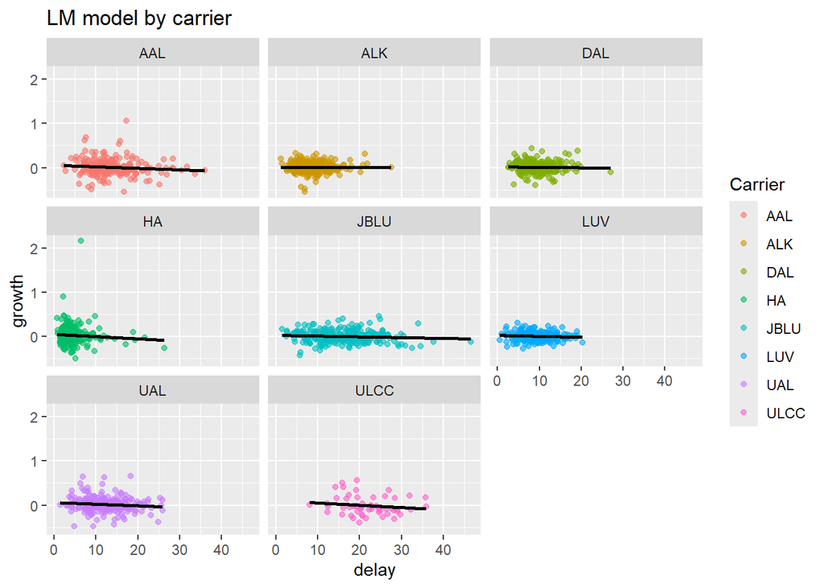

```r
av_delay_df %>%
  ggplot(aes(x= av_delay, y= grow, color= carrier))+
  geom_point(alpha= 0.6)+
  geom_smooth(method = "lm", se= F, color= "Black")+
    labs(
    title = "LM model by carrier",
    x = "delay",
    y = "growth",
    color = "Carrier"
  )+facet_wrap(~carrier)
```

```r
lm_carrier_table <- bind_rows(
  lapply(
    split(av_delay_df, av_delay_df$carrier),
    function(df) {
      model <- lm(grow ~ av_delay, data = df)
      s <- summary(model)

      data.frame(
        Carrier   = unique(df$carrier),
        Intercept = round(coef(model)[1], 4),
        av_delay  = round(coef(model)[2], 4),
        R2        = round(s$r.squared, 4),
        Adj_R2    = round(s$adj.r.squared, 4),
        p_value   = round(s$coefficients[2, "Pr(>|t|)"], 4),
        N         = nrow(df), row.names = unique(df$carrier)
      )
    }
  )
)
lm_carrier_table
```

```
##      Carrier Intercept av_delay     R2  Adj_R2 p_value   N
## AAL      AAL    0.0584  -0.0035 0.0108  0.0066  0.1083 241
## ALK      ALK    0.0117  -0.0003 0.0001 -0.0036  0.8580 269
## DAL      DAL    0.0201  -0.0009 0.0008 -0.0037  0.6688 221
## HA        HA    0.0495  -0.0051 0.0059  0.0019  0.2257 250
## JBLU    JBLU    0.0282  -0.0017 0.0087  0.0050  0.1277 269
## LUV      LUV    0.0253  -0.0021 0.0067  0.0030  0.1792 269
## UAL      UAL    0.0616  -0.0037 0.0118  0.0076  0.0955 236
## ULCC    ULCC    0.1032  -0.0052 0.0210  0.0022  0.2959  54
```

```r
#lm_carrier_table %>% write_csv(here("data","Carrier_pred.csv"))
```

```r
long_df <- av_delay_df %>%
  select(S_Date, Fuel_price, close) %>%
  mutate(Fuel_price= Fuel_price) %>%
  pivot_longer(cols = c(Fuel_price, close),
               names_to = "variable",
               values_to = "close")
```

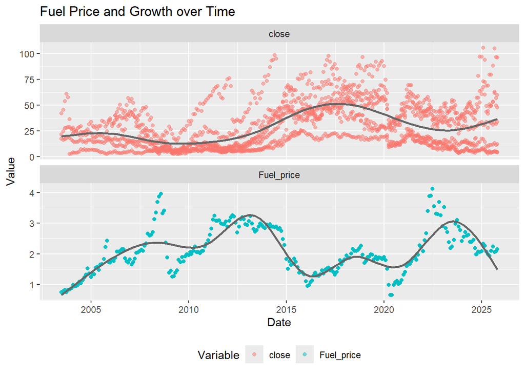

### Distribution of monthly stock returns

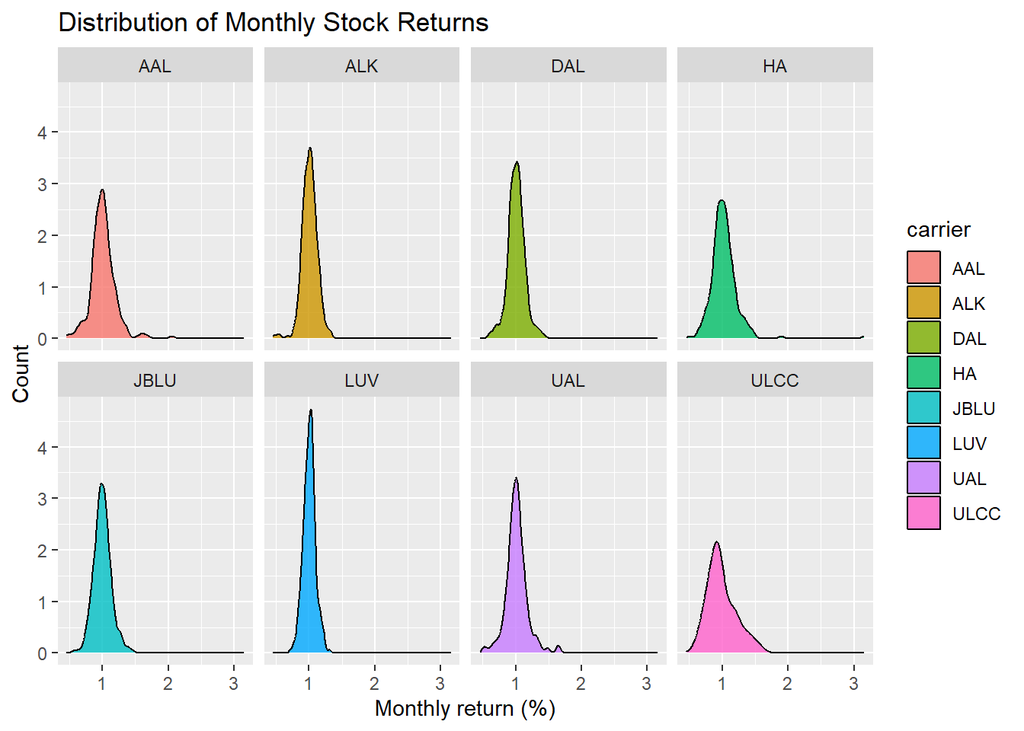

```r
ggplot(av_delay_df, aes(x = grow_log,fill= carrier)) +
  geom_density(bins = 40,alpha = 0.8) +
  facet_wrap(~carrier, nrow= 2)+
  labs(
    title = "Distribution of Monthly Stock Returns",
    x = "Monthly return (%)",
    y = "Count"
  )
```

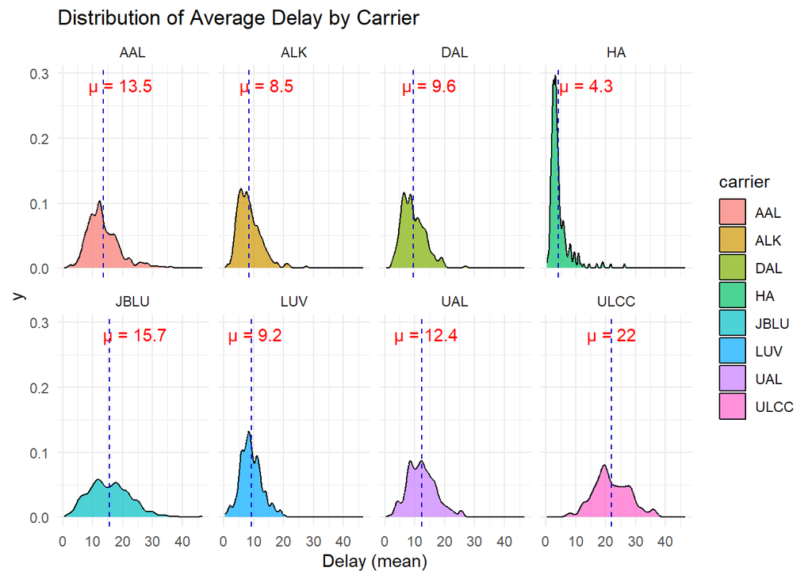

```r
mean_df <- av_delay_df %>%
  group_by(carrier) %>%
  summarise(mean_delay = mean(av_delay, na.rm = TRUE),
            xmin = min(av_delay, na.rm = TRUE),
            xmax = max(av_delay, na.rm = TRUE)) %>%
  mutate(label = paste0("\u03BC = ", round(mean_delay, 1)),
          x_mid = (xmin + xmax) / 2)

#mean_df %>% write_csv(here("data","late_mid_av.csv"))

ggplot(av_delay_df, aes(x = av_delay, fill = carrier)) +
  geom_density(adjust = 1/2, alpha = 0.7) +
  facet_wrap(~carrier, nrow = 2) +
  geom_vline(data = mean_df, aes(xintercept = mean_delay),
    color = "blue3",
    linetype = "dashed") +
  labs(
    title = "Distribution of Average Delay by Carrier",
    x = "Delay (mean)") +
  theme_minimal()+
geom_text(
  data = mean_df,
  aes(x = x_mid, y = Inf, label = label),
  vjust = 2,
  hjust = 0.5,
  color = "red")
```

```r
delay_long<-
  delay_data %>%
  select(carrier, year, month,
         carrier_delay, weather_delay, nas_delay,
         security_delay, late_aircraft_delay) %>%
  pivot_longer(
    cols = c(carrier_delay, weather_delay, nas_delay,
         security_delay, late_aircraft_delay),
    names_to = "Reason",
    values_to = "Delay_Min"
  ) %>%
    mutate(
    Reason = gsub("_delay$", "", Reason, ignore.case = TRUE)
  )

delay_share <- delay_long %>%
  group_by(carrier, Reason) %>%
  summarise(
    Total_Delay = sum(Delay_Min, na.rm = TRUE),
    .groups = "drop"
  ) %>%
  group_by(carrier) %>%
  mutate(
    Share = Total_Delay / sum(Total_Delay)
  )
```

### Delay composition by airline

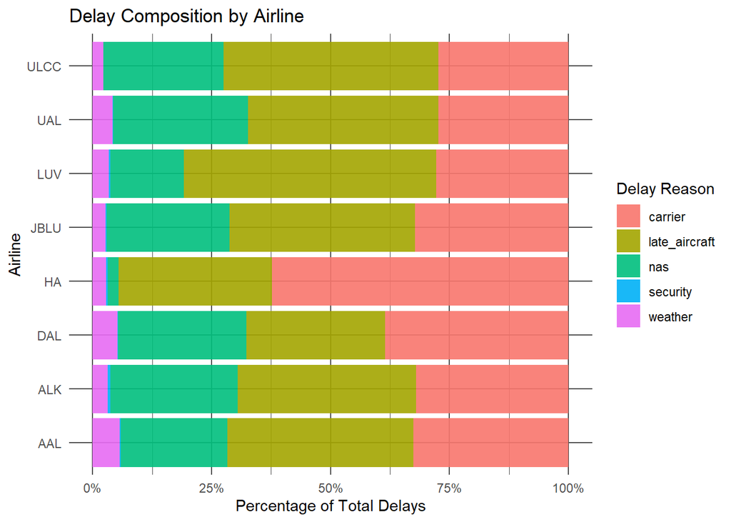

### Delay composition over time across all carriers

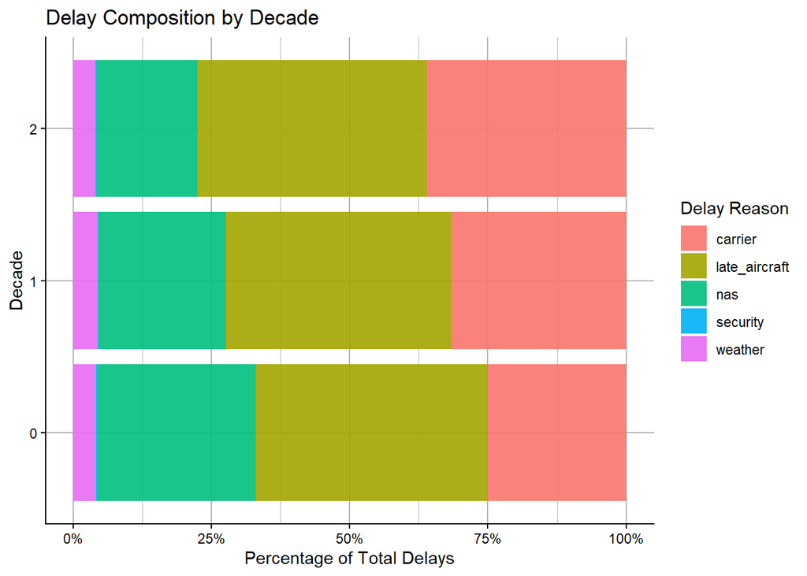

# Modeling

## Main Model

```r
glm_stock_simple <- glm(log(grow_log) ~ av_delay + factor(month) + carrier,
                        data = av_delay_df,
                        family = gaussian())
```

```r
summary(glm_stock_simple)
```

```
##
## Call:
## glm(formula = log(grow_log) ~ av_delay + factor(month) + carrier,
##     family = gaussian(), data = av_delay_df)
##
## Coefficients:
##                   Estimate Std. Error t value Pr(>|t|)
## (Intercept)      0.0203069  0.0183529   1.106  0.26867
## av_delay        -0.0020566  0.0007943  -2.589  0.00970 **
## factor(month)2  -0.0135002  0.0170472  -0.792  0.42851
## factor(month)3  -0.0381136  0.0170188  -2.240  0.02525 *
## factor(month)4  -0.0146255  0.0170240  -0.859  0.39039
## factor(month)5  -0.0038630  0.0169921  -0.227  0.82019
## factor(month)6  -0.0181844  0.0170451  -1.067  0.28619
## factor(month)7   0.0188835  0.0171110   1.104  0.26992
## factor(month)8   0.0031354  0.0169484   0.185  0.85325
## factor(month)9  -0.0088947  0.0170091  -0.523  0.60108
## factor(month)10  0.0336752  0.0169937   1.982  0.04767 *
## factor(month)11  0.0444104  0.0171902   2.583  0.00986 **
## factor(month)12  0.0273966  0.0171040   1.602  0.10938
## carrierALK      -0.0038987  0.0136079  -0.287  0.77452
## carrierDAL      -0.0003984  0.0140182  -0.028  0.97733
## carrierHA       -0.0041108  0.0151219  -0.272  0.78577
## carrierJBLU      0.0014089  0.0131190   0.107  0.91449
## carrierLUV      -0.0021809  0.0134643  -0.162  0.87135
## carrierUAL       0.0051124  0.0134598   0.380  0.70412
## carrierULCC     -0.0097959  0.0230647  -0.425  0.67110
## ---
## Signif. codes:  0 '***' 0.001 '**' 0.01 '*' 0.05 '.' 0.1 ' ' 1
##
## (Dispersion parameter for gaussian family taken to be 0.02150465)
##
##     Null deviance: 39.781  on 1808  degrees of freedom
## Residual deviance: 38.472  on 1789  degrees of freedom
## AIC: -1790
##
## Number of Fisher Scoring iterations: 2
```

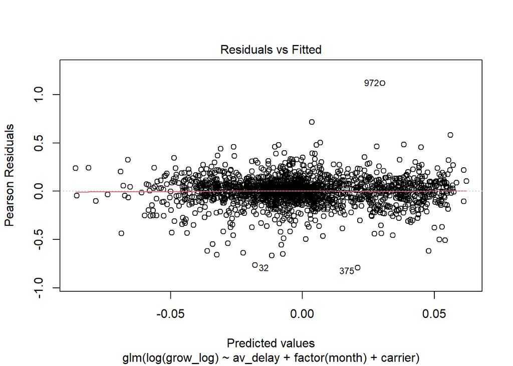

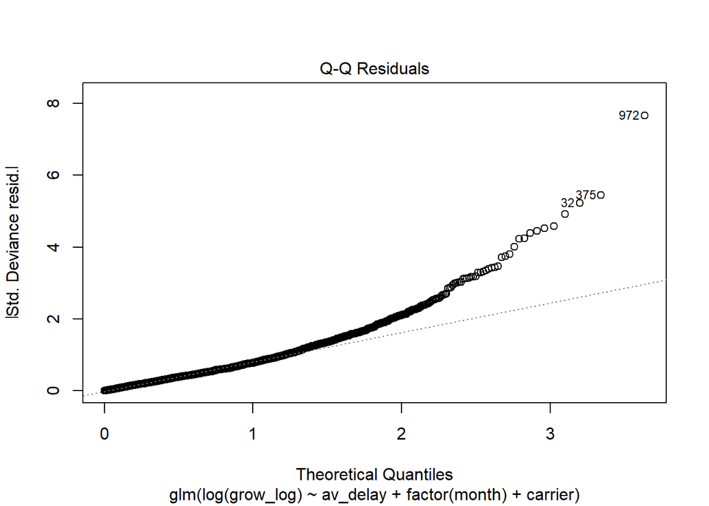

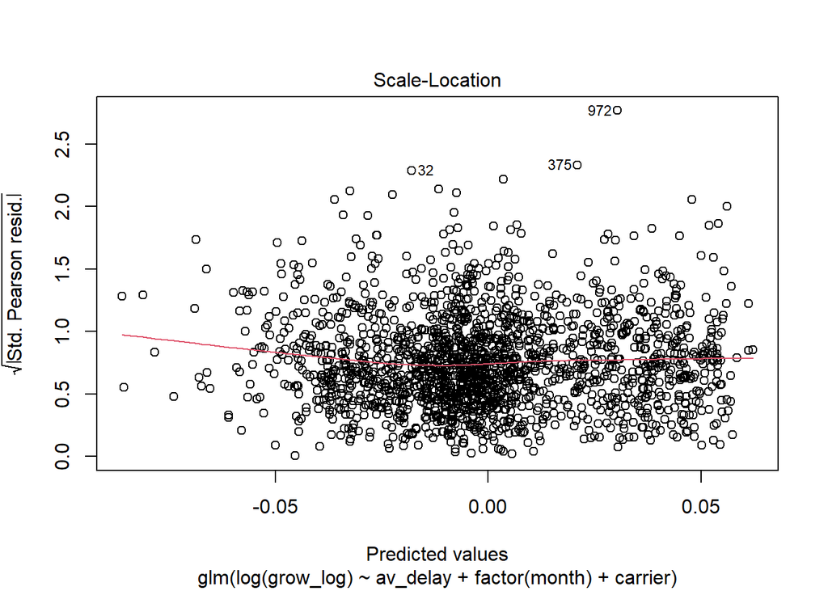

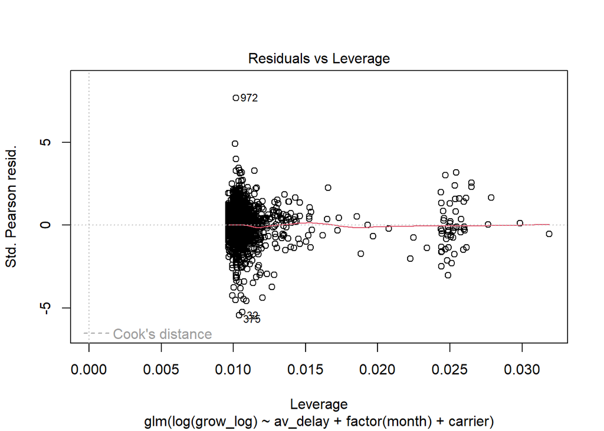

```r
glm_stock_simple %>% plot()
```